# Exploration of Prosper Loan Dataset

## Introduction

> This document explores a dataset from loans as gathered by Prosper(the first peer-to-peer lending marketplace in the United States) containing 113,937 listing keys with 81 variables on each key, including loan amount, borrower rate (or interest rate), current loan status, borrower income, IsBorrowerHomeowner(whether or not the borrower owns a home), and many others.

> The purpose of this analysis is to determine what factors influence the interest rate of borrowers' loan.

## Preliminary Wrangling

```python
# import all packages and set plots to be embedded inline
import numpy as np
import pandas as pd
import matplotlib.pyplot as plt
import seaborn as sb

%matplotlib inline
```

> Load in your dataset and describe its properties through the questions below. Try and motivate your exploration goals through this section.

```python
# Load dataset
loan_data = pd.read_csv('prosperLoanData.csv')

# Get data structure and datatypes
print(loan_data.shape)
print(loan_data.info())
```

```
(113937, 81)
<class 'pandas.core.frame.DataFrame'>
RangeIndex: 113937 entries, 0 to 113936
Data columns (total 81 columns):
 #   Column                               Non-Null Count   Dtype
---  ------                               --------------   -----
 0   ListingKey                           113937 non-null  object
 1   ListingNumber                        113937 non-null  int64
 2   ListingCreationDate                  113937 non-null  object
 3   CreditGrade                          28953 non-null   object
 4   Term                                 113937 non-null  int64
 5   LoanStatus                           113937 non-null  object
 6   ClosedDate                           55089 non-null   object
 7   BorrowerAPR                          113912 non-null  float64
 8   BorrowerRate                         113937 non-null  float64
```

[output cut: 75 more lines]

### What is the structure of your dataset?

> The dataset contains 113,937 loan records with 81 variables (including LoanOriginalAmount, BorrowerAPR, StatedMonthlyIncome, Term, ProsperRating (Alpha), IsBorrowerHomeowner, EmploymentStatus and many others). It also contains unique identifiers/primary keys which are found under the ListingKey and ListingNumber variables.

### What is/are the main feature(s) of interest in your dataset?

> When it comes to loans, while borrowers are more interested in obtaining loans at reasonable interest rates, lenders are more interested in recovering their money. Also, from the information above about the dataset, the BorrowerAPR column have 25 null values. Unlike interest rate(BorrowerRate), APR usually include charges or fees such as mortgage insurance, discount points, loan origination fee. It is therefore generally expected that the higher the interest rate, the higher the APR. On this note, my main feature of interest will be the BorrowerRate since BorrowerAPR has few null values. With this in mind, I am most interested in:
> 1. Finding out what features are best for predicting the borrower's Interest Rate(BorrowerRate) for the loan.
> 2. Borrowers' behaviour across months of the year.

### What features in the dataset do you think will help support your investigation into your feature(s) of interest?

> Loan amount, stated monthly income of borrowers, employment status and whether or not they are homeowners will have an effect on the interest rate of loans. I expect that since homes/buildings are substantial collaterals, homeowners will have access to bigger loans at lesser interest rates, since loans with collaterals are referred to as secured loans.

### Questions:

> 1. How does StatedMonthlyIncome, Prosper Rating, Employment Status, Income Range affect the interest rates of borrowers' loan?
> 2. Does whether or not a borrower own a home influence their interest rates and ability to obtain higher loan amounts?
> 3. What is the borrowing pattern of borrowers across months of the year.

> Before a loan is issued out by a loan bank, there must be a level of assurance pf the ability of the borrower to pay back the loan. StatedMonthlyIncome, Employment Status and Income Range are variables contained in the dataset which tells of the financial capacity of the borrower. For this reason, they will be used in determining effects on interest rates.

> Collaterals are also important factors to consider in loan listings. Being a homeowner could most likely increase a borrower's chance of getting higher loan amounts since loan banks categorize loans with collaterals as secured. The variable, IsBorrowerHomeowner would be used to investigate effects on Interest rates and loan amounts.

```python
# Change datatype of columns of interest
loan_data.rename(columns ={'ListingCategory (numeric)':'ListingCategory'}, inplace = True)
loan_data['ListingCreationDate'] = loan_data['ListingCreationDate'].astype('datetime64[ns]')
loan_data['ListingCategory'] = loan_data['ListingCategory'].astype(str)
```

```python
# Create new features that will facilitate exploration.
loan_data['ListingCreation_day'] = loan_data['ListingCreationDate'].dt.day_name()
loan_data['ListingCreation_month'] = loan_data['ListingCreationDate'].dt.month_name()
loan_data['ListingCreation_year'] = loan_data['ListingCreationDate'].dt.year

loan_data.head()
```

|  | ListingKey | ListingNumber | ListingCreationDate | CreditGrade | Term | LoanStatus | ClosedDate | BorrowerAPR | BorrowerRate | LenderYield | ... | LP_NetPrincipalLoss | LP_NonPrincipalRecoverypayments | PercentFunded | Recommendations | InvestmentFromFriendsCount | InvestmentFromFriendsAmount | Investors | ListingCreation_day | ListingCreation_month | ListingCreation_year |
| --- | --- | --- | --- | --- | --- | --- | --- | --- | --- | --- | --- | --- | --- | --- | --- | --- | --- | --- | --- | --- | --- |
| 0 | 1021339766868145413AB3B | 193129 | 2007-08-26 19:09:29.263 | C | 36 | Completed | 2009-08-14 00:00:00 | 0.16516 | 0.1580 | 0.1380 | ... | 0.0 | 0.0 | 1.0 | 0 | 0 | 0.0 | 258 | Sunday | August | 2007 |
| 1 | 10273602499503308B223C1 | 1209647 | 2014-02-27 08:28:07.900 | NaN | 36 | Current | NaN | 0.12016 | 0.0920 | 0.0820 | ... | 0.0 | 0.0 | 1.0 | 0 | 0 | 0.0 | 1 | Thursday | February | 2014 |
| 2 | 0EE9337825851032864889A | 81716 | 2007-01-05 15:00:47.090 | HR | 36 | Completed | 2009-12-17 00:00:00 | 0.28269 | 0.2750 | 0.2400 | ... | 0.0 | 0.0 | 1.0 | 0 | 0 | 0.0 | 41 | Friday | January | 2007 |
| 3 | 0EF5356002482715299901A | 658116 | 2012-10-22 11:02:35.010 | NaN | 36 | Current | NaN | 0.12528 | 0.0974 | 0.0874 | ... | 0.0 | 0.0 | 1.0 | 0 | 0 | 0.0 | 158 | Monday | October | 2012 |
| 4 | 0F023589499656230C5E3E2 | 909464 | 2013-09-14 18:38:39.097 | NaN | 36 | Current | NaN | 0.24614 | 0.2085 | 0.1985 | ... | 0.0 | 0.0 | 1.0 | 0 | 0 | 0.0 | 20 | Saturday | September | 2013 |

5 rows × 84 columns

## Univariate Exploration

> I'll start by looking at the distribution of interest rate(BorrowerRate) which is the main variable of interest.

```python
loan_data['BorrowerRate'].describe()
```

```
count    113937.000000
mean          0.192764
std           0.074818
min           0.000000
25%           0.134000
50%           0.184000
75%           0.250000
max           0.497500
Name: BorrowerRate, dtype: float64
```

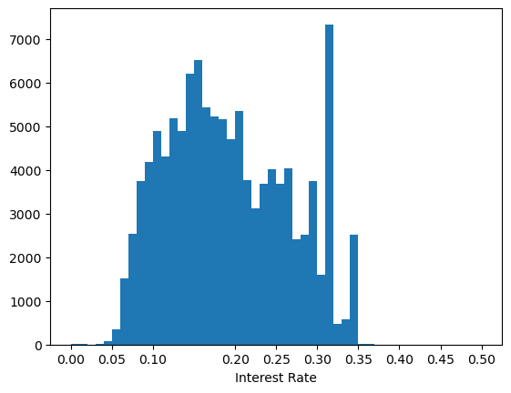

```python
bin_size = 0.01
bins = np.arange(0, loan_data['BorrowerRate'].max()+bin_size, bin_size)
plt.hist(data = loan_data, x = 'BorrowerRate', bins=bins);
plt.xticks([0, 0.05, 0.1, 0.2, 0.25, 0.3, 0.35, 0.4, 0.45, 0.5]);
plt.xlabel('Interest Rate')
```

The distribution of both BorrowerRate looks multimodal. There is a very sharp peak between 0.31 and 0.32. Only very few loans have interest rate gretaer than 0.35.

Next up, I'll look at the distribution of the first predictor variable of interest: LoanOriginalAmount

```python
loan_data['LoanOriginalAmount'].describe()
```

```
count    113937.00000
mean       8337.01385
std        6245.80058
min        1000.00000
25%        4000.00000
50%        6500.00000
75%       12000.00000
max       35000.00000
Name: LoanOriginalAmount, dtype: float64
```

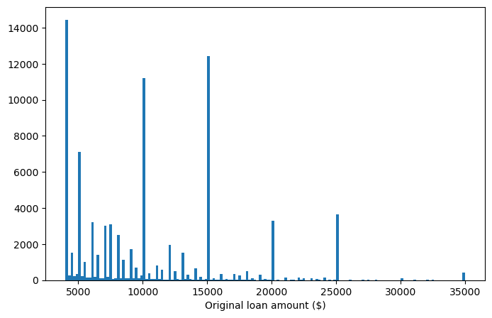

```python
bins = np.arange(4000, loan_data.LoanOriginalAmount.max()+200, 200)
plt.figure(figsize=[8, 5])
plt.hist(data = loan_data, x = 'LoanOriginalAmount', bins = bins);
plt.xlabel('Original loan amount ($)');
```

Large spikes/peaks are at 5000, 10000, 15000, 20000, 25000. At 4000, there is also a very large peak. This shows that loan amounts are usually multiples of 1000 and 5000.

Next, I'd inspect the distribution of the second variable of interest: StatedMonthlyIncome

```python
loan_data['StatedMonthlyIncome'].describe()
```

```
count    1.139370e+05
mean     5.608026e+03
std      7.478497e+03
min      0.000000e+00
25%      3.200333e+03
50%      4.666667e+03
75%      6.825000e+03
max      1.750003e+06
Name: StatedMonthlyIncome, dtype: float64
```

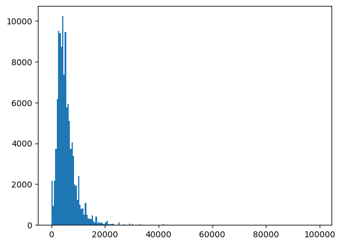

```python
# Distribution of stated monthly income
bins = np.arange(0, 100000, 500)
plt.hist(data = loan_data, x = 'StatedMonthlyIncome', bins=bins);
```

> The distibution of StatedMonthlyIncome is highly skewed to the right, with the income of most borrowers less than 40,000.

Following the distributions of quantitative variables of interest, I would like to examine the counts of qualitative variables of interest.

First is the ListingCategory (which represents the category of listing the borrower selected when posting their listings which is also basically what the borrower intends to use the loan for).

> According to the data dictionary, the ListingCategory is the number that the borrower selected when posting their listing: 0 - Not Available, 1 - Debt Consolidation, 2 - Home Improvement, 3 - Business, 4 - Personal Loan, 5 - Student Use, 6 - Auto, 7- Other, 8 - Baby&Adoption, 9 - Boat, 10 - Cosmetic Procedure, 11 - Engagement Ring, 12 - Green Loans, 13 - Household Expenses, 14 - Large Purchases, 15 - Medical/Dental, 16 - Motorcycle, 17 - RV, 18 - Taxes, 19 - Vacation, 20 - Wedding Loans

```python
# Using the data dictionary, I will replace the numerical values with the category they represent.

loan_data = loan_data.replace({'ListingCategory' : {'0' : 'Not available', '1' : 'Debt consolidation', '2' : 'Home improvement', '3' : 'Business', '4' : 'Personal loan', '5' : 'Student use', '6' : 'Auto', '7' : 'Other', '8' : 'Baby/Adoption', '9' : 'Boat', '10' : 'Cosmetic procedure', '11' : 'Engagement ring', '12' : 'Green loans', '13' : 'Household', '14' : 'Large purchases', '15' : 'Medical/Dental', '16' : 'Motorcycle', '17' : 'RV', '18' : 'Taxes', '19' : 'Vacation', '20' : 'Wedding loans'}})
```

```python
# Confirm that changes have been implemented
loan_data.ListingCategory.value_counts()
```

```
Debt consolidation    58308
Not available         16965
Other                 10494
Home improvement       7433
Business               7189
Auto                   2572
Personal loan          2395
Household              1996
Medical/Dental         1522
Taxes                   885
Large purchases         876
Wedding loans           771
Vacation                768
Student use             756
Motorcycle              304
Engagement ring         217
Baby/Adoption           199
Cosmetic procedure       91
Boat                     85
Green loans              59
RV                       52
Name: ListingCategory, dtype: int64
```

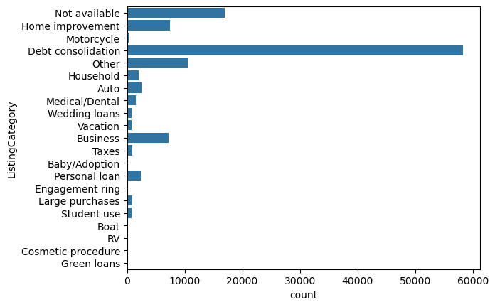

```python
# Plot the bar chart in the decreasing order of the frequency of the `ListingCategory`
base_color = sb.color_palette()[0]
sb.countplot(data=loan_data, y='ListingCategory', color=base_color);
```

> The bar chart above shows an absolute frequency with Debt Consolidation having the highest count of more than 50,000, unlike other listing categories with counts less than 20,000. For better accuracy, let's look at the relative frequencies of these listing categories:

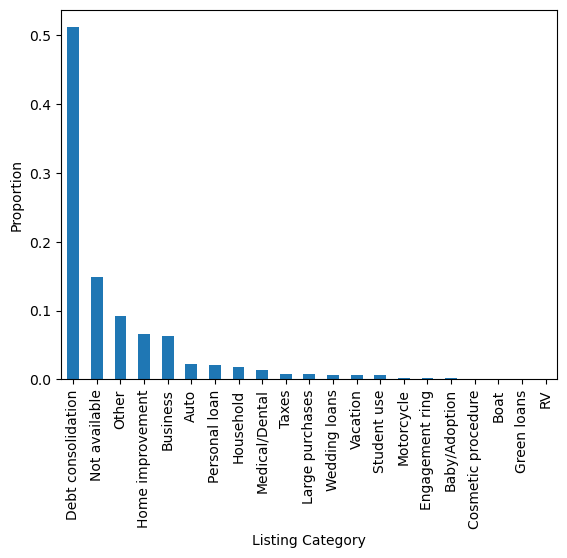

```python
# Get the counts of each listing category
counts = loan_data['ListingCategory'].value_counts()

# Get the total number of all non-null values in the ListingCategory varible/column
total = loan_data['ListingCategory'].count()
total

# Calculate the proportion of each listing category
proportion = counts/total

# Plot the bar chart for the proportions
proportion.plot(kind='bar', color=sb.color_palette()[0]);
plt.xlabel('Listing Category')
plt.ylabel('Proportion')
```

> The barchart above on relative frequencies shows that unlike proportions of other listing categories which have proportions less than 0.2, Debt Consolidation has a proportion greater than 0.5. This shows that persons who applied for loans for the purpose of debt consolidation where far greater than those who applied for loans for other purposes.

Next, I will look at the fequencies of the month in which loans were applied for using the variable, ListingCreation_month:

```python
# Create an ordered categorical type of all the categorical variables of interest.

income = ['Not displayed', 'Not employed', '$0', '$1-24,999', '$25,000-49,999', '$50,000-74,999', '$75,000-99,999', '$100,000+']
income_range = pd.api.types.CategoricalDtype(ordered=True, categories = income)
loan_data['IncomeRange'] = loan_data['IncomeRange'].astype(income_range)


status = ['Not available', 'Not employed', 'Employed', 'Part-time', 'Full-time', 'Self-employed', 'Retired', 'Other']
employment_status = pd.api.types.CategoricalDtype(ordered=True, categories = status)
loan_data['EmploymentStatus'] = loan_data['EmploymentStatus'].astype(employment_status)


rating_order = ['HR','E','D','C','B','A','AA']
ordered_rating = pd.api.types.CategoricalDtype(ordered = True, categories = rating_order)
loan_data['ProsperRating (Alpha)'] = loan_data['ProsperRating (Alpha)'].astype(ordered_rating)


month_order = ['January','February','March','April','May','June','July', 'August', 'September', 'October', 'November', 'December']
ordered_month = pd.api.types.CategoricalDtype(ordered = True, categories = month_order)
loan_data['ListingCreation_month'] = loan_data['ListingCreation_month'].astype(ordered_month)
```

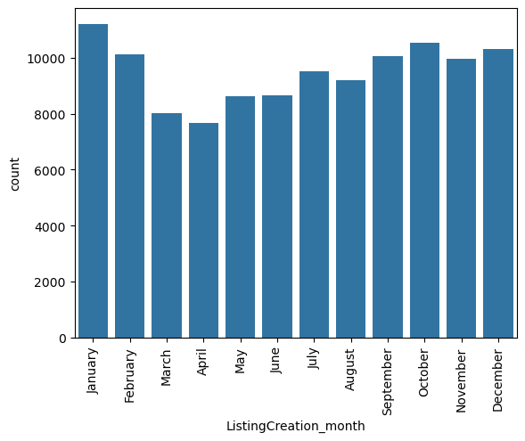

```python
base_color = sb.color_palette()[0]
sb.countplot(data = loan_data, x = 'ListingCreation_month', color = base_color)
plt.xticks(rotation=90);
```

> The month of January has the highest number of listing creation.

Look at distributions of Employment status, Income range, Term and Prosper rating.

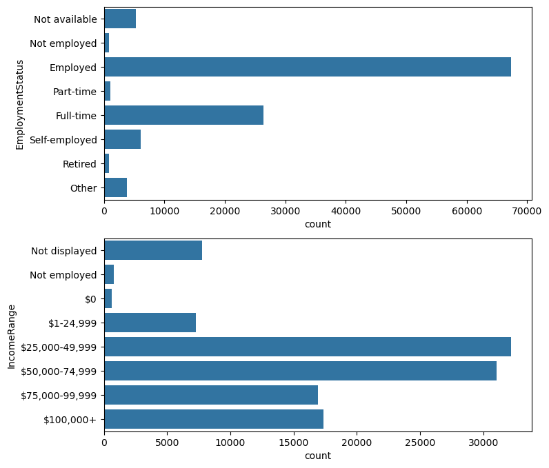

```python
status = ['Not available', 'Not employed', 'Employed', 'Part-time', 'Full-time', 'Self-employed', 'Retired', 'Other']
employment_status = pd.api.types.CategoricalDtype(ordered=True, categories = status)
loan_data['EmploymentStatus'] = loan_data['EmploymentStatus'].astype(employment_status)


base_color = sb.color_palette()[0]
fig, ax = plt.subplots(nrows=2, figsize = [8,8])

sb.countplot(data = loan_data, y= 'EmploymentStatus', color = base_color, ax = ax[0])
sb.countplot(data = loan_data, y = 'IncomeRange', color = base_color, ax = ax[1])
```

> Most borrowers are employed and work full time. Most employed borrowers earn between 25k 𝑡𝑜 75k dollars.

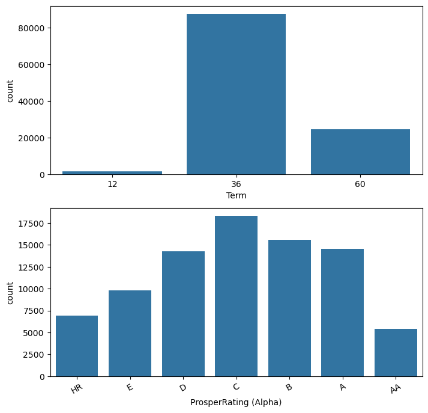

```python
fig, ax = plt.subplots(nrows=2, figsize = [8,8])
base_color = sb.color_palette()[0]
sb.countplot(data = loan_data, x = 'Term', color = base_color, ax = ax[0])
sb.countplot(data = loan_data, x = 'ProsperRating (Alpha)', color = base_color, ax = ax[1])

plt.xticks(rotation=30);
```

> More than 80,000 loans have a loan term of 36 months. Most borrowers rated loans from D to A. The highest rating(AA) was given by few of the borrowers.

### Discuss the distribution(s) of your variable(s) of interest. Were there any unusual points? Did you need to perform any transformations?

> The distribution of interest rate(BorrowerRate) looks multimodal. Most of the values are at the range of 0.05 and 0.4. More borrowers seem to request for loan amounts in multples of 1000, and Debt Consolidation was the highest reason borrowers listed as the purpose of the loan.

### Of the features you investigated, were there any unusual distributions? Did you perform any operations on the data to tidy, adjust, or change the form of the data? If so, why did you do this?

> The distributions of stated monthly income is highly skewed to the right. Most stated monthly incomes are less than $40k, but some of them are incredibly high, like greater than 100k. Surprisingly, most of borrowers with greater than 100k monthly income only loan less than 5k dollars. So, the very large stated monthly income may be made up. Overall, Less than 0.3 percent borrowers have stated monthly income greater than 30k, these can be seemed as outlier for the following analysis, so it is better to remove borrower records with income greater than 30k.

To tidy the data in order to enable addition of relevant features like ListingCreation_month, I changed the datatype for ListingCreationDate from object to datetime. This is to help me figure out the loan application pattern/trend of borrowers across the year.

For ListingCategory variable, column name and datatype was changed, and values had to be replaced from numerical listings to categorical listings as indicated on the data dictionary . This is because, since listings number from 1-20, creating a legend for the purpose of visualization would be cumbersome or distracting to the audience.

```python
loan_data['ListingCategory'].value_counts()
```

```
Debt consolidation    58308
Not available         16965
Other                 10494
Home improvement       7433
Business               7189
Auto                   2572
Personal loan          2395
Household              1996
Medical/Dental         1522
Taxes                   885
Large purchases         876
Wedding loans           771
Vacation                768
Student use             756
Motorcycle              304
Engagement ring         217
Baby/Adoption           199
Cosmetic procedure       91
Boat                     85
Green loans              59
RV                       52
Name: ListingCategory, dtype: int64
```

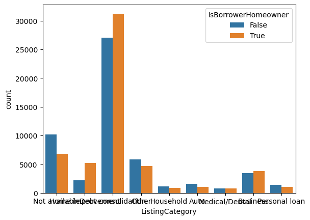

```python
# Extract loan_data with listing categories selected by more than 1000 borrowers.
loan_data_sub = loan_data.loc[loan_data['ListingCategory'].isin(['Debt consolidation', 'Not available', 'Other', 'Home improvement', 'Business', 'Auto', 'Personal loan', 'Household', 'Medical/Dental'])]

# Plot clustered bar chart
sb.countplot(data = loan_data_sub, x = 'ListingCategory', hue = 'IsBorrowerHomeowner')
```

> The clustered chart above shows that more than 30,000 borrowers who listed Debt Consolidation are home owners. This may mean that the loans were used to pay off house mortagages.

Next, I want to look at the relationship present between features in the data. To start off, I want to look at the pairwise correlations present between features in the data.

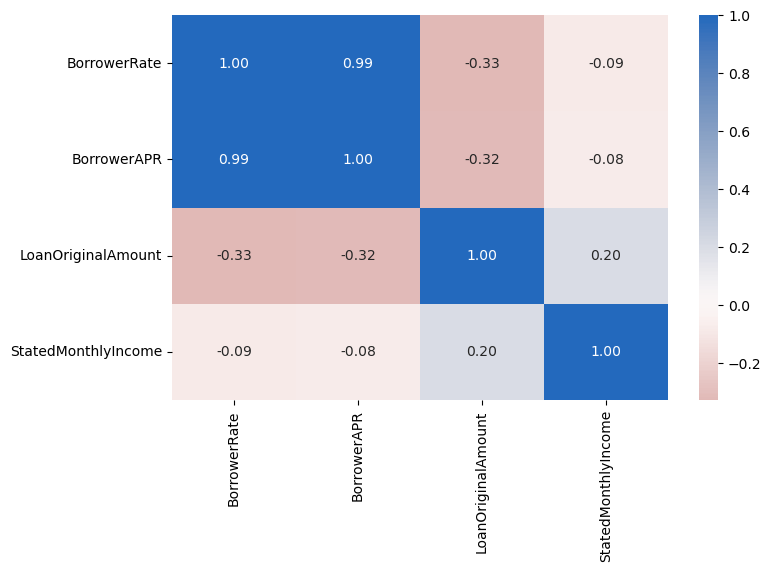

```python
# correlation plot

num_vars = ['BorrowerRate', 'BorrowerAPR', 'LoanOriginalAmount', 'StatedMonthlyIncome']
cat_vars = ['Term', 'ProsperRating (Alpha)', 'EmploymentStatus', 'IncomeRange']
plt.figure(figsize = [8, 5])
sb.heatmap(loan_data[num_vars].corr(), annot = True, fmt = '.2f',
           cmap = 'vlag_r', center = 0);
```

> Since most borrowers have their stated monthly income to be less than $40000, I'd extract borrowers' data whose monthly income falls below 40,000 and see if this improves the correlation coefficients.

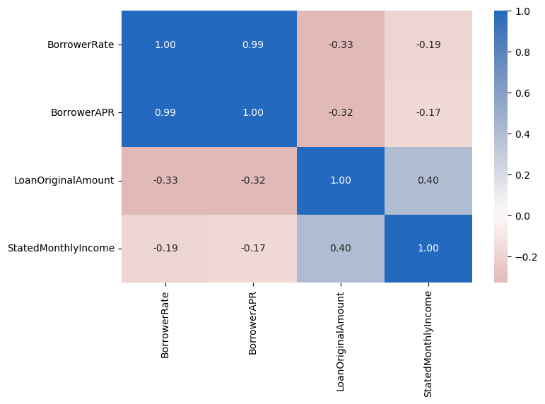

```python
loan_data_sub = loan_data.loc[loan_data['StatedMonthlyIncome'] <= 40000]

# correlation plot

num_vars = ['BorrowerRate', 'BorrowerAPR', 'LoanOriginalAmount', 'StatedMonthlyIncome']
plt.figure(figsize = [8, 5])
sb.heatmap(loan_data_sub[num_vars].corr(), annot = True, fmt = '.2f',
           cmap = 'vlag_r', center = 0);
```

> The correlation coefficient did improve as a result of the removal of less occuring monthly income. Correlation between StatedMonthlyIncome and Loan Amount became more positive with a coefficient of 0.4, showing that borrowers with higher monthly income would have access to more loan amount. The correlation coefficient of Interest rate and loan original amount is -0.33. This shows that these two variables are negatively correlated, which agrees with our hypothesis, that is the more the loan amount, the lower the interest rate.

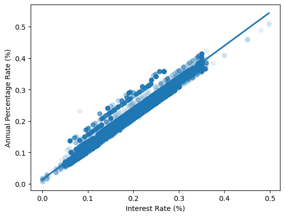

```python
sb.regplot(data=loan_data, x = 'BorrowerRate', y = 'BorrowerAPR', truncate=True, scatter_kws={'alpha':1/10})
plt.xlabel('Interest Rate (%)')
plt.ylabel('Annual Percentage Rate (%)')
```

> There is a strong positive correlation between APR nd Interest Rate, with a correlation coefficient of 0.99. the higher the interest rate, the higher the APR. Prediction for null APR values in the dataset can be done using the Interest Rates of the loan amount. This confirms the expectation that with the inclusion of charges or fees such as mortgage insurance, discount points, loan origination fee, APRs are proportional to Interest Rates. This also explains why the relationship between APR and interest rate versus loan amount look very similar.

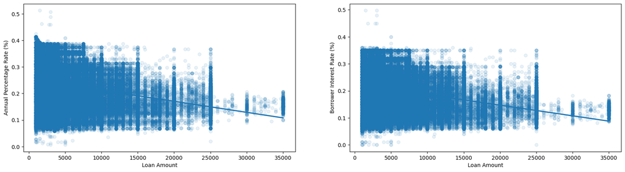

```python
plt.figure(figsize=[20,5])

plt.subplot(1,2,1)
sb.regplot(data=loan_data, x = 'LoanOriginalAmount', y = 'BorrowerAPR', truncate=True, scatter_kws={'alpha':1/10})
plt.xlabel('Loan Amount')
plt.ylabel('Annual Percentage Rate (%)')

plt.subplot(1,2,2)
sb.regplot(data=loan_data, x = 'LoanOriginalAmount', y = 'BorrowerRate', truncate=True, scatter_kws={'alpha':1/10})
plt.xlabel('Loan Amount')
plt.ylabel('Borrower Interest Rate (%)')
```

> The scatter plot above shows the relationship between loan amount vs. APR and loan amount vs. interest rate. It shows that both APR nd interest rates are negatively correlated to loan amount. An increase in the latter results in a decrease in the former. Using this information, missing BorrowerAPR values can be predicted using the interest rate of the corresponding loan.

I will move on to looking at how borrower APR, stated monthly income and loan original amount correlate with the categorical variables:

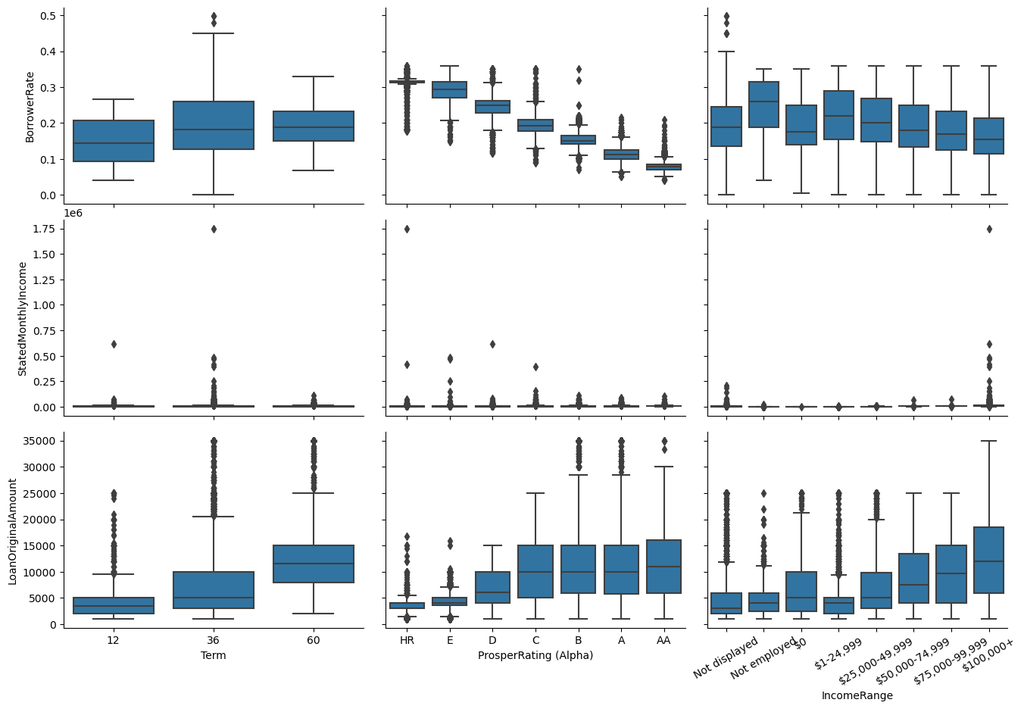

```python
# Plot matrix of numeric features against categorical features

num_var = ['BorrowerRate', 'StatedMonthlyIncome', 'LoanOriginalAmount']
cat_vars = ['Term', 'ProsperRating (Alpha)', 'IncomeRange']

def boxgrid(x, y, **kwargs):
    """ Quick hack for creating box plots with seaborn's PairGrid. """
    base_color = sb.color_palette()[0]
    sb.boxplot(x, y, color = base_color)

plt.figure(figsize = [10, 10])
g = sb.PairGrid(data = loan_data, y_vars = num_var,
                x_vars = cat_vars, size = 3, aspect = 1.5)
g.map(boxgrid);
plt.xticks(rotation=30);
```

> It means that the Prosper rating has a strong effect on borrower APR. Borrowers with better rating also have larger loan amount. Employed, self-employed and full time borrowers have more monthly income and loan amount than part-time, retired and not employed borrowers.

> While interest rate decreases with increased income range, loan amount increases with increased income range with borrowers with borrowers whose income are greater than $100k receiving the highest loan amounts. The higher the income range, the higher the loan amount.

Next, I will view the relationship between Employment status and other numerical variables of interest:

```
(array([0, 1, 2, 3, 4, 5, 6, 7]),
 [Text(0, 0, 'Not available'),
```

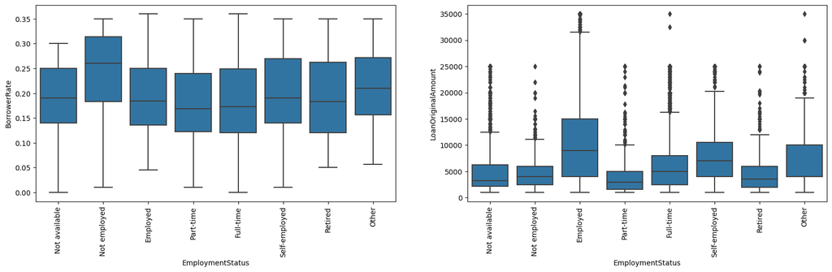

```python
# Boxplot showing the relationship between BorrowerRate and LoanOriginalAmount vs. EmploymentStatus
plt.figure(figsize=[20,5])

plt.subplot(1,2,1)
sb.boxplot(data=loan_data_sub, x='EmploymentStatus', y='BorrowerRate', color=base_color)
plt.xticks(rotation=90)

plt.subplot(1,2,2)
sb.boxplot(data=loan_data_sub, x='EmploymentStatus', y='LoanOriginalAmount', color=base_color)
plt.xticks(rotation=90)
```

> Due to high number of outliers and since most stated monthly income are less than 40𝑘, 𝑡ℎ𝑒 𝑃𝑎𝑖𝑟𝐺𝑟𝑖𝑑 𝑜𝑓 𝑏𝑜𝑥𝑝𝑙𝑜𝑡𝑠 𝑎𝑏𝑜𝑣𝑒 𝑤ℎ𝑖𝑐ℎ 𝑠ℎ𝑜𝑤𝑠 𝑡ℎ𝑒 𝑟𝑒𝑙𝑎𝑡𝑖𝑜𝑛𝑠ℎ𝑖𝑝 𝑏𝑒𝑡𝑤𝑒𝑒𝑛 𝑆𝑡𝑎𝑡𝑒𝑑𝑀𝑜𝑛𝑡ℎ𝑙𝑦𝐼𝑛𝑐𝑜𝑚𝑒 𝑎𝑛𝑑 𝑜𝑡ℎ𝑒𝑟 𝑐𝑎𝑡𝑒𝑔𝑜𝑟𝑖𝑐𝑎𝑙 𝑣𝑎𝑟𝑖𝑎𝑏𝑙𝑒𝑠 𝑜𝑓 𝑖𝑛𝑡𝑒𝑟𝑒𝑠𝑡 𝑠ℎ𝑜𝑤𝑠 𝑚𝑜𝑟𝑒 𝑛𝑢𝑚𝑏𝑒𝑟 𝑜𝑓 𝑜𝑢𝑡𝑙𝑖𝑒𝑟𝑠. 𝑊𝑖𝑡ℎ 𝑡ℎ𝑖𝑠 𝑖𝑛 𝑚𝑖𝑛𝑑, 𝐼′𝑙𝑙 𝑡𝑎𝑘𝑒 𝑜𝑢𝑡 𝑠𝑜𝑚𝑒 𝑜𝑓 𝑡ℎ𝑒 𝑜𝑢𝑡𝑙𝑖𝑒𝑟𝑠(𝑤ℎ𝑖𝑐ℎ 𝑎𝑟𝑒 𝑚𝑜𝑠𝑡𝑙𝑦 𝑠𝑡𝑎𝑡𝑒𝑑 𝑖𝑛𝑐𝑜𝑚𝑒 𝑔𝑟𝑒𝑎𝑡𝑒𝑟 𝑡ℎ𝑎𝑛 40k as shown in the histogram of StatedMonthlyIncome).

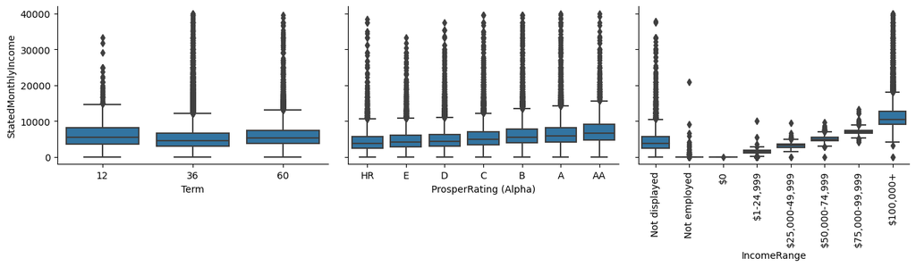

```python
# Using the loan_data_sub(a subset of the data containing records of borrowers whose stated monthly income are less than or equal to 40,000)


def boxgrid(x, y, **kwargs):
    """ Quick hack for creating box plots with seaborn's PairGrid. """
    default_color = sb.color_palette()[0]
    sb.boxplot(x, y, color = default_color)

plt.figure(figsize = [10, 10])
g = sb.PairGrid(data = loan_data_sub, y_vars = ['StatedMonthlyIncome'],
                x_vars = ['Term', 'ProsperRating (Alpha)', 'IncomeRange'], size = 3, aspect = 1.5)
g.map(boxgrid);
plt.xticks(rotation=90);
```

> Borrowers with better rating also have larger monthly income.

```
(array([0, 1, 2, 3, 4, 5, 6, 7]),
 [Text(0, 0, 'Not available'),
```

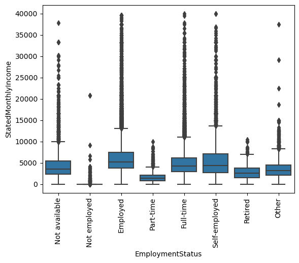

```python
sb.boxplot(data=loan_data_sub, x='EmploymentStatus', y='StatedMonthlyIncome', color=base_color)
plt.xticks(rotation=90)
```

> Employed, self-employed and full time borrowers have more monthly income and loan amount than part-time, retired and not employed borrowers.

> Borrowers who are employed receive more loan amounts.

Finally, let's look at relationships between the some categorical features:

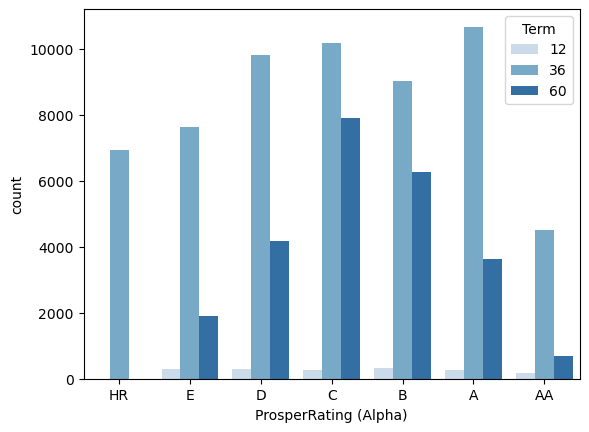

```python
# Prosper rating vs term

sb.countplot(data = loan_data, x = 'ProsperRating (Alpha)', hue = 'Term', palette = 'Blues')
```

> There is a interaction between term and Prosper rating. Overall, there are more 36-month loans across all ratings besides HR rating. There is only 36 months loans for HR rating borrowers.

Next, I'd investigate in which month(s) borrowers applied for loans the most and how this relates to the loan amount.

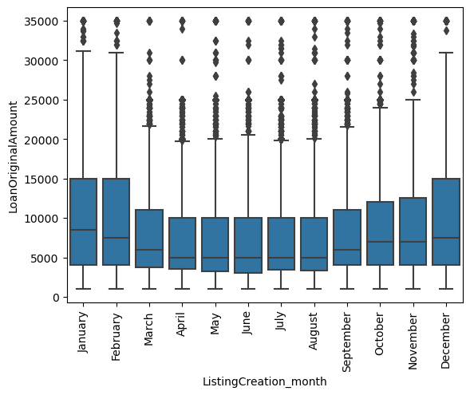

```python
sb.boxplot(data=loan_data, x='ListingCreation_month', y='LoanOriginalAmount', color=base_color)
plt.xticks(rotation=90);
```

### Talk about some of the relationships you observed in this part of the investigation. How did the feature(s) of interest vary with other features in the dataset?

> The interest rate(BorrowerRate) is negatively associated with the loan original amount, which mean the more the loan amount, the lower the interest rate. Increased income range amounts to increased loan amounts. Increased loan amounts amounts to lower interest rates. Lower interest rates amounts to better ratings.

> Borrowers who enjoy lower interest rates give better ratings.

### Did you observe any interesting relationships between the other features (not the main feature(s) of interest)?

> More borrowers who listed Debt consolidation in the ListingCategory variable are home owners. This may be because the loans are intended to be used to pay of house mortagages or buy a house. The loan original amount is positively correlated with the stated monthly income, it makes sense since borrowers with more monthly income could loan more money.

## Multivariate Exploration

> In this section, I would like to investigate how:
> 1. The categorical variables, ratings(ProsperRating) and whether or not borrower is a home owner(IsBorrowerHomeowner) affects the relationship between interest rate and loan amount.
> 2. rating and term effects on stated monthly income and loan original amount variables

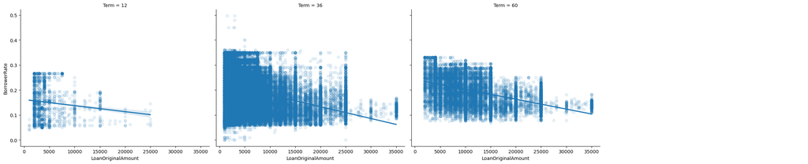

```python
# Term effect on relationship of APR and loan amount
g=sb.FacetGrid(data=loan_data_sub, aspect=1.2, size=5, col='Term', col_wrap=4)
g.map(sb.regplot, 'LoanOriginalAmount', 'BorrowerRate', x_jitter=0.04, scatter_kws={'alpha':0.1});
g.add_legend();
```

> Loan term doesn't seem to have any effect ion the relationship between Interest Rate and loan amount.

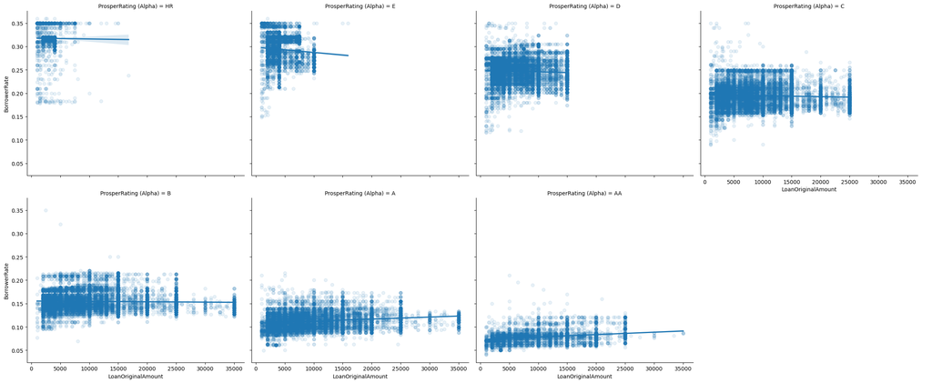

```python
# Prosper rating effect on relationship of APR and loan amount
g=sb.FacetGrid(data=loan_data_sub, aspect=1.2, size=5, col='ProsperRating (Alpha)', col_wrap=4)
g.map(sb.regplot, 'LoanOriginalAmount', 'BorrowerRate', x_jitter=0.04, scatter_kws={'alpha':0.1});
g.add_legend();
```

> The loan amount increases with better rating. The interest rate decreases with better rating. Interestingly, the relationship between interest rate and loan amount turns from negative to slightly positive when the Prosper ratings are increased from HR to AA.

> Increased income range amounts to increased loan amounts. Increased loan amounts amounts to lower interest rates. Lower interest rates amounts to better ratings.

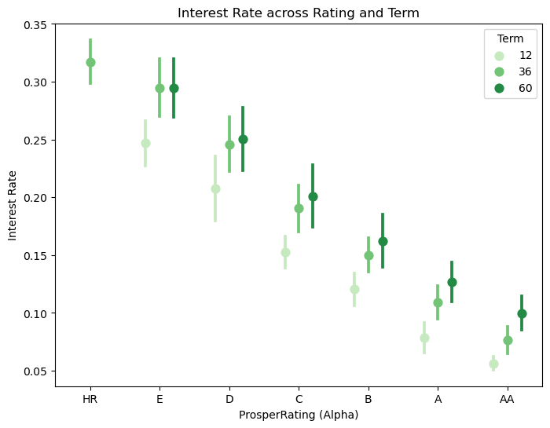

```python
fig = plt.figure(figsize = [8,6])
ax = sb.pointplot(data = loan_data, x = 'ProsperRating (Alpha)', y = 'BorrowerRate', hue = 'Term',
           palette = 'Greens', linestyles = '', dodge = 0.4, ci='sd')
plt.title('Interest Rate across Rating and Term')
plt.ylabel('Interest Rate')
ax.set_yticklabels([],minor = True);
```

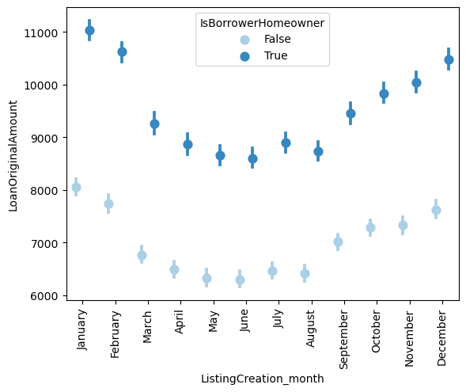

```python
sb.pointplot(data = loan_data, x = 'ListingCreation_month', y = 'LoanOriginalAmount', hue = 'IsBorrowerHomeowner',
           palette = 'Blues', linestyles = '', dodge = 0.4);
plt.xticks(rotation=90);
```

> Borrowing behaviour of both home owners and non-homeowners look the same across different period of the year, except that comapared to non-homeowners, home owners borrow more money. This may be for debt consolidation of house mortagages as seen in the bivariate relationship between ListingCategory and IsBorrowerHomeowner.

Next, I'll investigate if being a homeowner influences the relationship between loan amount and interest rate.

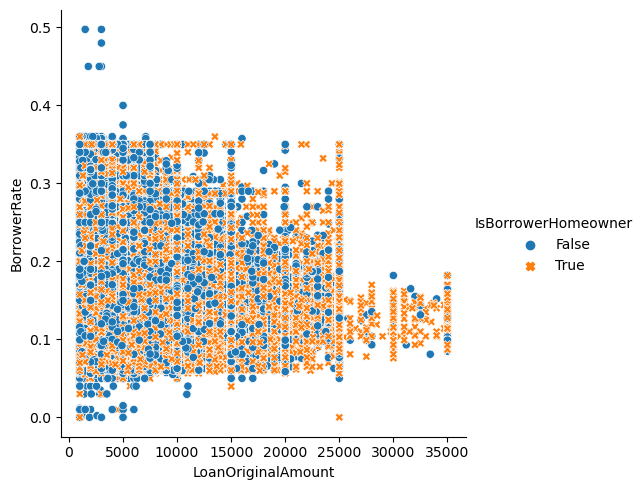

```python
sb.relplot(
    data=loan_data,
    x="LoanOriginalAmount", y="BorrowerRate", hue="IsBorrowerHomeowner", style="IsBorrowerHomeowner"
)
```

> Homeowners are probably able to access more loan amounts with respect to the current value of the home. This is because the loaners need assurance that they will be able to get back all their money if the borrower isn't able to keep up with payment. Also, for borrowers(non-homeowners)who get high interest rate even at low loan amounts, this could be because these loans are not secured as they do not involve collateral. Secured loans usually have lower interest rates than unsecured loans because the bank has a way to recoup its money if you do not pay.

### Talk about some of the relationships you observed in this part of the investigation. Were there features that strengthened each other in terms of looking at your feature(s) of interest?

> In the multivariate exploration of data, I observed the relationship between Interest rate(BorrowerRate) and loan amount by looking at the impact of the Prosper rating. The multivariate exploration showed that the relationship between borrower APR and loan amount turns from negative to slightly positive when the Prosper ratings increased from HR to AA. It was observed that borrowing pattern of both homeowners and non-homeowners are similar across the months of the year. But, compared to non-homeowners, homeowners borrowed more money.